# Data Exploration with Python and Jupyter

Basic usage of the Pandas library to download a dataset, explore its contents, clean up missing or invalid data, filter the data according to different criteria, and plot visualizations of the data.

- [Part 1: Python and Jupyter](https://ssciwr.github.io/jupyter-data-exploration)
- **Part 2: Pandas with toy data**
- [Part 3: Pandas with real data](https://ssciwr.github.io/jupyter-data-exploration/pandas-real-data.slides.html)

*Press `Spacebar` to go to the next slide (or `?` to see all navigation shortcuts)*

# Pandas

is a data analysis and manipulation Python library

```python
# Import the Pandas library
import pandas as pd
```

```python
# Import some toy data as a pandas DataFrame
df = pd.read_csv("https://ssciwr.github.io/jupyter-data-exploration/data.csv")
```

```python
type(df)
```

```
pandas.core.frame.DataFrame
```

```python
len(df)
```

```
20
```

```python
# Display the first few rows of data
df.head()
```

|  | Name | Age | Sex | Height | Eye colour | Wears glasses |
| --- | --- | --- | --- | --- | --- | --- |
| 0 | Bob | 12 | Male | 130.0 | blue | yes |
| 1 | Simon | 13 | Male | 120.0 | blue | no |
| 2 | Clare | 15 | Female | 142.5 | green | no |
| 3 | Jose | 11 | Male | 117.0 | brown | no |
| 4 | Hannah | 9 | Female | 111.0 | blue | yes |

```python
# Display general DataFrame info (columns, entries, types)
df.info()
```

```
<class 'pandas.core.frame.DataFrame'>
RangeIndex: 20 entries, 0 to 19
Data columns (total 6 columns):
 #   Column         Non-Null Count  Dtype
---  ------         --------------  -----
 0   Name           20 non-null     object
 1   Age            20 non-null     int64
 2   Sex            20 non-null     object
 3   Height         20 non-null     float64
 4   Eye colour     20 non-null     object
 5   Wears glasses  20 non-null     object
dtypes: float64(1), int64(1), object(4)
memory usage: 1.1+ KB
```

# Selecting rows and columns

Three main ways of doing this:

- Python-style indexing operator `[]`
- Pandas `loc` function (label-based)
- Pandas `iloc` function (index-based)

We'll start with the more intuitive Python-style methods, and later move into the more powerful `loc` and `iloc` alternatives

```python
# A DataFrame is a bit like a Dictionary - we can lookup columns by name
names = df["Name"]
```

```python
# A column of a DataFrame is a Series
type(names)
```

```
pandas.core.series.Series
```

```python
names.head()
```

```
0       Bob
1     Simon
2     Clare
3      Jose
4    Hannah
Name: Name, dtype: object
```

```python
# A Series is a bit like a List - we can select items by index
names[0]
```

```
'Bob'
```

```python
# Here are the first three items:
names[0:3]
```

```
0      Bob
1    Simon
2    Clare
Name: Name, dtype: object
```

```python
# Can also iterate over items
for name in names:
    print(name, "", end="")
```

```
Bob Simon Clare Jose Hannah Ryan Craig Suzy Chris Josie Claire John Agnes Robert Julia Fabian Joseph Roberta Chris Lucas
```

```python
# alternative syntax: dataframe.column_name
# both of these are equivalent:
ages1 = df["Age"]
print(ages1.head())

ages2 = df.Age
print(ages2.head())

# note: this only works if the column label is a valid python object name, e.g. can't contain a space
```

```
0    12
1    13
2    15
3    11
4     9
Name: Age, dtype: int64
0    12
1    13
2    15
3    11
4     9
Name: Age, dtype: int64
```

# iloc

- select data based on its *location*
- first specify row(s), then column(s): `df.iloc[row, col]`
- treating dataset as a matrix, or a list of lists
- note: slices are *exclusive*, i.e. `df.iloc[0:2]` returns rows 0 and 1, but not 2

```python
# First row of data (column is implicitly "all" if not specified)
df.iloc[0]
```

```
Name               Bob
Age                 12
Sex               Male
Height           130.0
Eye colour        blue
Wears glasses      yes
Name: 0, dtype: object
```

```python
# First row of data (using : slice operator to select all columns)
df.iloc[0, :]
```

```
Name               Bob
Age                 12
Sex               Male
Height           130.0
Eye colour        blue
Wears glasses      yes
Name: 0, dtype: object
```

```python
# First column of data
df.iloc[:, 0].head()
```

```
0       Bob
1     Simon
2     Clare
3      Jose
4    Hannah
Name: Name, dtype: object
```

```python
# Can select slices of rows and columns: e.g. first 3 rows, last 2 columns
df.iloc[0:3, -2:]
```

|  | Eye colour | Wears glasses |
| --- | --- | --- |
| 0 | blue | yes |
| 1 | blue | no |
| 2 | green | no |

```python
# Can also select a list of indices, e.g. rows 3,5,7, columns 3,5
df.iloc[[3, 5, 7], [3, 5]]
```

|  | Height | Wears glasses |
| --- | --- | --- |
| 3 | 117.0 | no |
| 5 | 124.0 | no |
| 7 | 137.0 | yes |

# loc

- select data based on its index *label* and column *label*, instead of location
- first specify row(s), then column(s): `df.loc[:, "Name"]`
- often the most useful method
- note: slices are *inclusive*, i.e. `df.loc[0:2]` returns rows 0 and 1 *and* 2
- note: in our example, the index label is a number, and it is the same as the row index, but in general this is not the case

```python
# Row with index label "0" (column is implicitly "all" if not specified)
df.loc[0]
```

```
Name               Bob
Age                 12
Sex               Male
Height           130.0
Eye colour        blue
Wears glasses      yes
Name: 0, dtype: object
```

```python
# Row with index label "0" (using : slice operator to select all columns)
df.loc[0, :]
```

```
Name               Bob
Age                 12
Sex               Male
Height           130.0
Eye colour        blue
Wears glasses      yes
Name: 0, dtype: object
```

```python
# "Name" column of data (using : slice operator to select all rows)
df.loc[:, "Name"].head()
```

```
0       Bob
1     Simon
2     Clare
3      Jose
4    Hannah
Name: Name, dtype: object
```

```python
# Can also select a list of labels, e.g. index labels 3,5,7, columns "Height","Wears glasses"
df.loc[[3, 5, 7], ["Height", "Wears glasses"]]
```

|  | Height | Wears glasses |
| --- | --- | --- |
| 3 | 117.0 | no |
| 5 | 124.0 | no |
| 7 | 137.0 | yes |

# Conditionals

- a statement that is either true or false
  - `a == b` : true if `a` is equal to `b`
  - `a != b` : true if `a` is not equal to `b`
  - `a > b` : true if `a` is greater than `b`
  - `a >= b` : true if `a` is greater than or equal to `b`
  - `a < b` : true if `a` is less than `b`
  - `a <= b` : true if `a` is less than or equal to `b`
- they can be combined
  - `a & b` : true if a and b are both true, otherwise false
  - `a | b` : true if a or b is true, otherwise false
- if `a` is a pandas Series, the result is a Boolean Series
  - with a True or False result for each row
  - which can be used by loc to select data
- this is very flexible and powerful

```python
# This returns True, as the condition 10 > 9 is true
10 > 9
```

```
True
```

```python
# Similarly, this returns False, as the condition 8 > 9 is false
8 > 9
```

```
False
```

```python
# Can do the same with a Series - returns a Boolean (true/false) Series
df["Age"] > 9
```

```
0      True
1      True
2      True
3      True
4     False
5      True
6      True
7      True
8      True
9     False
10     True
11    False
12    False
13    False
14    False
15    False
16    False
17     True
18    False
19    False
Name: Age, dtype: bool
```

```python
# loc can take this as the selection, e.g. older than 9
df.loc[df["Age"] > 9]
```

|  | Name | Age | Sex | Height | Eye colour | Wears glasses |
| --- | --- | --- | --- | --- | --- | --- |
| 0 | Bob | 12 | Male | 130.0 | blue | yes |
| 1 | Simon | 13 | Male | 120.0 | blue | no |
| 2 | Clare | 15 | Female | 142.5 | green | no |
| 3 | Jose | 11 | Male | 117.0 | brown | no |
| 5 | Ryan | 11 | Male | 124.0 | brown | no |
| 6 | Craig | 12 | Male | 124.0 | brown | no |
| 7 | Suzy | 14 | Female | 137.0 | grey | yes |
| 8 | Chris | 10 | Male | 112.5 | brown | no |
| 10 | Claire | 16 | Female | 158.0 | blue | no |
| 17 | Roberta | 11 | Female | 121.0 | grey | no |

```python
# can combine conditions with & e.g. older than 9 and have blue eyes
df.loc[(df["Age"] > 9) & (df["Eye colour"] == "blue")]
# note: good idea to wrap each condition in brackets when combining them
```

|  | Name | Age | Sex | Height | Eye colour | Wears glasses |
| --- | --- | --- | --- | --- | --- | --- |
| 0 | Bob | 12 | Male | 130.0 | blue | yes |
| 1 | Simon | 13 | Male | 120.0 | blue | no |
| 10 | Claire | 16 | Female | 158.0 | blue | no |

```python
# can have multiple conditions with | e.g. younger than 7 or wears glasses
df.loc[(df["Age"] < 7) | (df["Wears glasses"] == "yes")]
```

|  | Name | Age | Sex | Height | Eye colour | Wears glasses |
| --- | --- | --- | --- | --- | --- | --- |
| 0 | Bob | 12 | Male | 130.0 | blue | yes |
| 4 | Hannah | 9 | Female | 111.0 | blue | yes |
| 7 | Suzy | 14 | Female | 137.0 | grey | yes |
| 11 | John | 5 | Male | 97.0 | grey | no |
| 12 | Agnes | 6 | Female | 98.0 | blue | yes |
| 14 | Julia | 3 | Female | 63.0 | blue | no |
| 15 | Fabian | 5 | Male | 101.0 | blue | no |
| 16 | Joseph | 8 | Male | 107.0 | brown | yes |
| 19 | Lucas | 2 | Male | 59.0 | blue | no |

# Summarizing data

Some useful functions for getting a quick overview of a Series:

- `describe()`
  - for numerical data: mean, min, max, std deviation, etc
  - for strings: count, number of unique items, most common item
- `count()` - the number of items in a Series
- `unique()` - a list of the unique items in a Series
- `value_counts()` - the count of each unique item in a Series
- `plot()` - plot numerical data on the y-axis (with the Index on the x-axis)
- `hist()` - plot a histogram of frequency of each unique item

You can also use these methods on the whole DataFrame, but only numerical data columns will be considered.

```python
df["Eye colour"].describe()
```

```
count       20
unique       4
top       blue
freq         8
Name: Eye colour, dtype: object
```

```python
df["Eye colour"].count()
```

```
20
```

```python
df["Eye colour"].unique()
```

```
array(['blue', 'green', 'brown', 'grey'], dtype=object)
```

```python
df["Eye colour"].value_counts()
```

```
Eye colour
blue     8
brown    8
grey     3
green    1
Name: count, dtype: int64
```

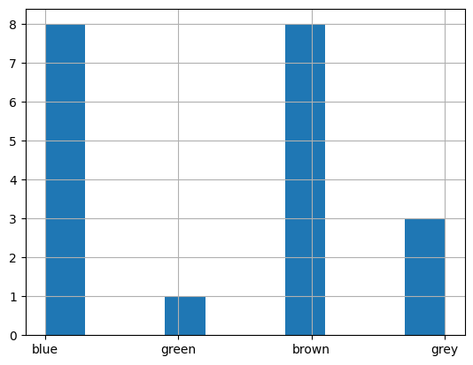

```python
df["Eye colour"].hist()
```

```python
df["Height"].describe()
```

```
count     20.000000
mean     112.200000
std       23.283945
min       59.000000
25%      104.750000
50%      111.750000
75%      124.000000
max      158.000000
Name: Height, dtype: float64
```

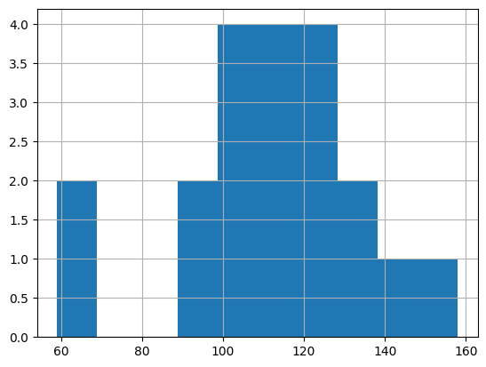

```python
df["Height"].hist()
```

# Plotting

# Matplotlib

- terminology
  - `figure`: the "canvas" on which plots will be made
  - `axis`: a plot - a figure can have one or several of these
  - these are implicitly created if you don't do so yourself
- useful commands
  - `ax = plt.subplot()`: create an axis you can pass to Pandas to plot on
  - `fig, axs = plt.subplots(ncols=3)`: create a figure and multiple axes you can pass to Pandas to plot on
  - `plt.savefig("plot.png")`: save the plot as an image

```python
# import matplotlib

import matplotlib.pyplot as plt
```

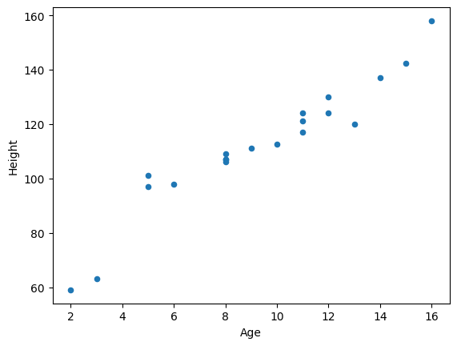

```python
# see how two columns are correlated with a scatter plot
df.plot.scatter(x="Age", y="Height")
```

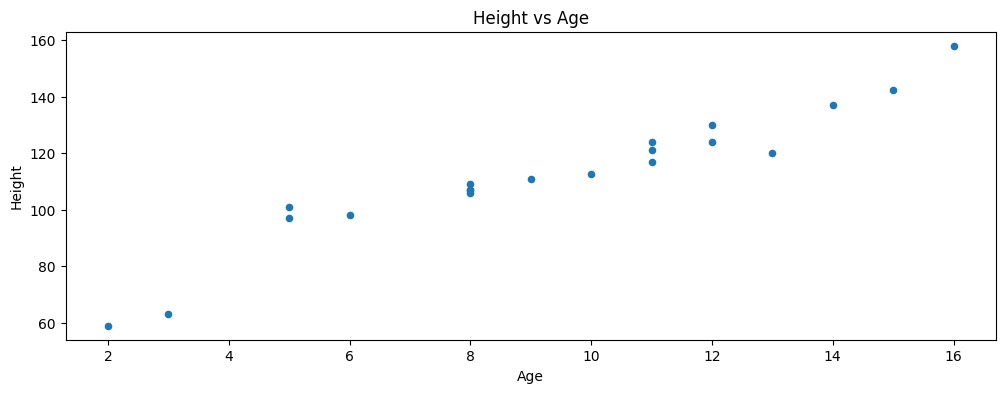

```python
# do the same thing, but use matplotlib to customise the plot
# make a larger figure
fig, axs = plt.subplots(figsize=(12, 4))
# pass our axis to pandas plot
df.plot.scatter(x="Age", y="Height", ax=axs)
# set a title
plt.title("Height vs Age")
# display the plot
plt.show()
```

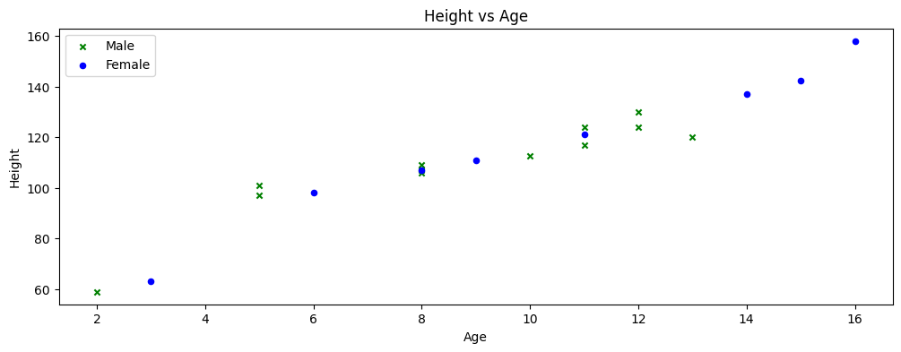

```python
# filter the data before plotting, and plot multiple labelled datapoints
fig, axs = plt.subplots(figsize=(12, 4))
df.loc[df["Sex"] == "Male"].plot.scatter(
    x="Age", y="Height", ax=axs, label="Male", marker="x", color="green"
)
df.loc[df["Sex"] == "Female"].plot.scatter(
    x="Age", y="Height", ax=axs, label="Female", marker="o", color="blue"
)
plt.legend()
plt.title("Height vs Age")
plt.show()
```

```
[]
```

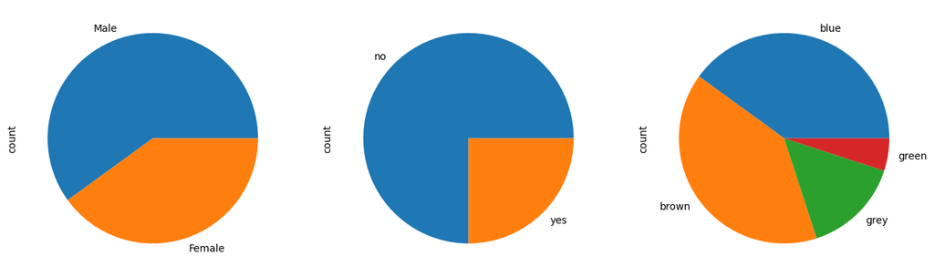

```python
fig, axs = plt.subplots(nrows=1, ncols=3, figsize=(16, 6))
df["Sex"].value_counts().plot.pie(ax=axs[0])
df["Wears glasses"].value_counts().plot.pie(ax=axs[1])
df["Eye colour"].value_counts().plot.pie(ax=axs[2])
plt.plot()
```

```
[]
```

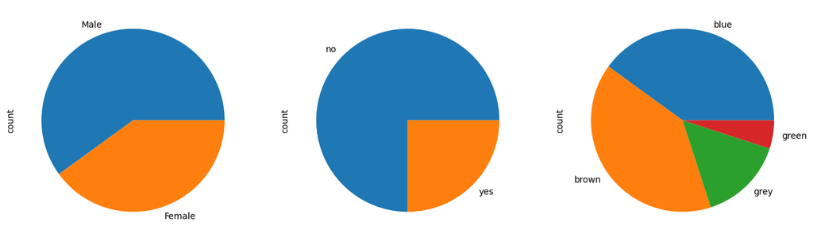

```python
fig, axs = plt.subplots(nrows=1, ncols=3, figsize=(16, 6))
for ax, column in zip(axs, ["Sex", "Wears glasses", "Eye colour"]):
    df[column].value_counts().plot.pie(ax=ax)
plt.plot()
```

# Groupby

- **split** the data into groups
- **apply** some function to each group
- **combine** the results

```python
grouped = df.groupby(["Sex"])
```

```python
type(grouped)
```

```
pandas.core.groupby.generic.DataFrameGroupBy
```

```python
grouped.groups
```

```
{'Female': [2, 4, 7, 9, 10, 12, 14, 17], 'Male': [0, 1, 3, 5, 6, 8, 11, 13, 15, 16, 18, 19]}
```

```python
for group, data in grouped:
    print(group)
    print(data.head())
```

```
('Female',)
      Name  Age     Sex  Height Eye colour Wears glasses
2    Clare   15  Female   142.5      green            no
4   Hannah    9  Female   111.0       blue           yes
7     Suzy   14  Female   137.0       grey           yes
9    Josie    8  Female   107.0      brown            no
10  Claire   16  Female   158.0       blue            no
('Male',)
    Name  Age   Sex  Height Eye colour Wears glasses
0    Bob   12  Male   130.0       blue           yes
1  Simon   13  Male   120.0       blue            no
3   Jose   11  Male   117.0      brown            no
5   Ryan   11  Male   124.0      brown            no
6  Craig   12  Male   124.0      brown            no
```

```python
df.groupby(["Sex"])["Age"].count()
```

```
Sex
Female     8
Male      12
Name: Age, dtype: int64
```

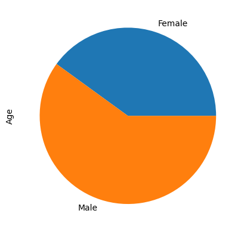

```python
df.groupby(["Sex"])["Age"].count().plot.pie()
```

```python
# equivalent "by hand" version
index = []
data = []
# split by sex
for group in df.Sex.unique():
    # apply "count" function to each subset
    count = df.loc[df.Sex == group].Age.count()
    # combine results back into a series
    index.append(group)
    data.append(count)
count_by_age = pd.Series(index=index, data=data, name="Age")
```

```python
count_by_age
```

```
Male      12
Female     8
Name: Age, dtype: int64
```

```python
# can group-by multiple columns
multigroup = df.groupby(["Eye colour", "Sex"]).Name.count()
multigroup
```

```
Eye colour  Sex
blue        Female    4
            Male      4
brown       Female    1
            Male      7
green       Female    1
grey        Female    2
            Male      1
Name: Name, dtype: int64
```

```python
# for plotting, unstack is helpful: converts our multi-index series into a dataframe with inner index as columns
multigroup.unstack()
```

| Sex Eye colour | Female | Male |
| --- | --- | --- |
| blue | 4.0 | 4.0 |
| brown | 1.0 | 7.0 |
| green | 1.0 | NaN |
| grey | 2.0 | 1.0 |

```
array([<Axes: ylabel='Female'>, <Axes: ylabel='Male'>], dtype=object)
```

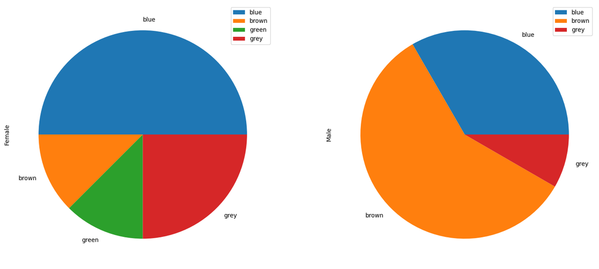

```python
multigroup.unstack().plot.pie(subplots=True, figsize=(18, 8))
```

```python
# custom apply function: count people older than 10 years old
def count_older_than_ten(series):
    return series.loc[series > 10].count()


df.groupby(["Sex"])["Age"].apply(count_older_than_ten)
```

```
Sex
Female    4
Male      5
Name: Age, dtype: int64
```

```python
# same thing with a lambda instead of defining a function
df.groupby(["Sex"])["Age"].apply(lambda x: x.loc[x > 10].count())
```

```
Sex
Female    4
Male      5
Name: Age, dtype: int64
```

# Types

- Default type is `Object`, aka String
- Pandas tries to identify types like numbers, dates and booleans
- Can also tell Pandas what type a column should be
- Using the correct type has multiple benefits
  - better performance (use less RAM, faster to run)
  - more functionality (e.g. summary / plots of numerical types)

```python
# display type of each column
df.dtypes
```

```
Name              object
Age                int64
Sex               object
Height           float64
Eye colour        object
Wears glasses     object
dtype: object
```

```python
# display memory usage of each column
df.memory_usage(deep=True)
```

```
Index             128
Name             1241
Age               160
Sex              1236
Height            160
Eye colour       1229
Wears glasses    1185
dtype: int64
```

```python
# list unique values in "Sex" column:
df["Sex"].unique()
```

```
array(['Male', 'Female'], dtype=object)
```

```python
# see how much RAM is used to store this column as strings
df["Sex"].memory_usage(deep=True)
```

```
1364
```

```python
# convert to a category type
df["Sex"] = df["Sex"].astype("category")
```

```python
# list unique values in column:
df["Sex"].unique()
```

```
['Male', 'Female']
Categories (2, object): ['Female', 'Male']
```

```python
# check RAM usage now
df["Sex"].memory_usage(deep=True)
```

```
380
```

```python
# do the same for eye colour
df["Eye colour"] = df["Eye colour"].astype("category")
```

```python
# list unique values to confirm Wears glasses is really a boolean:
df["Wears glasses"].unique()
```

```
array(['yes', 'no'], dtype=object)
```

```python
# see how much RAM is used to store this column as strings
df["Wears glasses"].memory_usage(deep=True)
```

```
1313
```

```python
# convert "yes" to True, "no" to False
df["Wears glasses"] = df["Wears glasses"].map({"yes": True, "no": False})
df["Wears glasses"].unique()
```

```
array([ True, False])
```

```python
df["Wears glasses"].memory_usage(deep=True)
```

```
148
```

# Next

- [Part 3: Pandas with real data](https://ssciwr.github.io/jupyter-data-exploration/pandas-real-data.slides.html)